# Patient Segmentation Based on Prescription Patterns

### Importing Necessary Libraries:

```python
from warnings import filterwarnings
filterwarnings('ignore')

import pandas as pd
import numpy as np
import seaborn as sns
import plotly.graph_objs as go
import matplotlib.pyplot as plt
from sklearn.cluster import KMeans
```

### Reading the data, Understanding the data and Addressing basic inconsistencies if any...

```python
df = pd.read_parquet('train.parquet')
df.head()
```

|  | Patient-Uid | Date | Incident |
| --- | --- | --- | --- |
| 0 | a0db1e73-1c7c-11ec-ae39-16262ee38c7f | 2019-03-09 | PRIMARY_DIAGNOSIS |
| 1 | a0dc93f2-1c7c-11ec-9cd2-16262ee38c7f | 2015-05-16 | PRIMARY_DIAGNOSIS |
| 3 | a0dc94c6-1c7c-11ec-a3a0-16262ee38c7f | 2018-01-30 | SYMPTOM_TYPE_0 |
| 4 | a0dc950b-1c7c-11ec-b6ec-16262ee38c7f | 2015-04-22 | DRUG_TYPE_0 |
| 8 | a0dc9543-1c7c-11ec-bb63-16262ee38c7f | 2016-06-18 | DRUG_TYPE_1 |

```python
df.shape
```

```
(3220868, 3)
```

```python
df.duplicated().sum()
```

```
35571
```

```python
df.index.duplicated().sum()
```

```
166693
```

```python
df.drop_duplicates(inplace = True)
df.reset_index(drop = True, inplace = True)
df.shape
```

```
(3185297, 3)
```

We have already understood the data well enough in `001.ipynb`... So, let's straightaway jump into the context...

Our matter of importance lies with only the patient who took target drug atleast once... So, let's split that alone from main dataframe and use it to cluster and analyse...

### Pulling just the positive set out of original dataset...

```python
positive_set = df[df['Incident'] == 'TARGET DRUG']
print(positive_set.shape)
positive_set.head()
```

```
(67218, 3)
```

|  | Patient-Uid | Date | Incident |
| --- | --- | --- | --- |
| 2065342 | a0eb742b-1c7c-11ec-8f61-16262ee38c7f | 2020-04-09 | TARGET DRUG |
| 2065362 | a0edaf09-1c7c-11ec-a360-16262ee38c7f | 2018-06-12 | TARGET DRUG |
| 2065502 | a0e9fa0e-1c7c-11ec-8dc7-16262ee38c7f | 2019-06-11 | TARGET DRUG |
| 2065613 | a0ecc615-1c7c-11ec-aa31-16262ee38c7f | 2019-11-15 | TARGET DRUG |
| 2065618 | a0ea612f-1c7c-11ec-8cf0-16262ee38c7f | 2020-03-18 | TARGET DRUG |

So, we have 67k + instances where patients took target drug and as we have already observed in `001.ipynb`, the total no. of unique patients who took target drug is around 9300 which is 1/3rd of total no. of unique patients in the entire dataset...

As all that incident column would have is just the Target Drug, it's of no use and so, let's drop it off...

```python
positive_set.drop('Incident', inplace = True, axis = 1)
```

```python
# Sorting patients by Patient-uid and date to manage them better

positive_set.sort_values(by=['Patient-Uid', 'Date'], inplace=True)
```

### Engineering new feature...

Extracting a new feature which shows the time interval between each prescription using the date column that we have would help us train the model and get clusters based on it... So, that's what we are going to do below...

Steps are simple...

1. Adding a new column to positive set df and assigning values to it by grouping based on Patient-uid and using diff method to compute diff between one date to another...
2. Dropping null values in TimeInterval column as all we would have for the first date would be NaT values (Not a Time)...

Let's do it...

```python
positive_set['TimeInterval'] = positive_set.groupby('Patient-Uid')['Date'].diff()

prescription_patterns = positive_set.copy()

prescription_patterns.dropna(subset=['TimeInterval'], inplace=True)
```

```python
print(prescription_patterns['TimeInterval'].min(), prescription_patterns['TimeInterval'].max())
```

```
1 days 00:00:00 1219 days 00:00:00
```

```python
print(df['Date'].min(), df['Date'].max())
```

```
2015-04-07 00:00:00 2020-09-03 00:00:00
```

```python
print(positive_set['Date'].min(), positive_set['Date'].max())
```

```
2017-02-22 00:00:00 2020-09-03 00:00:00
```

The time interval as we can observe spans between 1 day to 1219 days...

Also from the subsequent cells we can notice that while the dataset has records starting from Apr 2015 and ends by Sep 2020, the targe drug administration has got started only by Feb 2017 and ends by the date up till which we have records... We will discuss this later on if needed...

**Now let's find ideal no. of clusters using elbow method for k-means clustering... As we have time-delta object as input for the model, DB-scan won't take such input... So, let's stick to k-means clustering...**

### Elbow Plot to find ideal no. of clusters:

```
{'1 Cluster': 8.596245577653992e+35, '2 Clusters': 4.237133518141459e+35, '3 Clusters': 2.4248190479612254e+35, '4 Clusters': 1.3773206859526056e+35, '5 Clusters': 1.165582461295304e+35, '6 Clusters': 7.009182021866456e+34, '7 Clusters': 5.067819584613085e+34, '8 Clusters': 4.035829757754878e+34, '9…
```

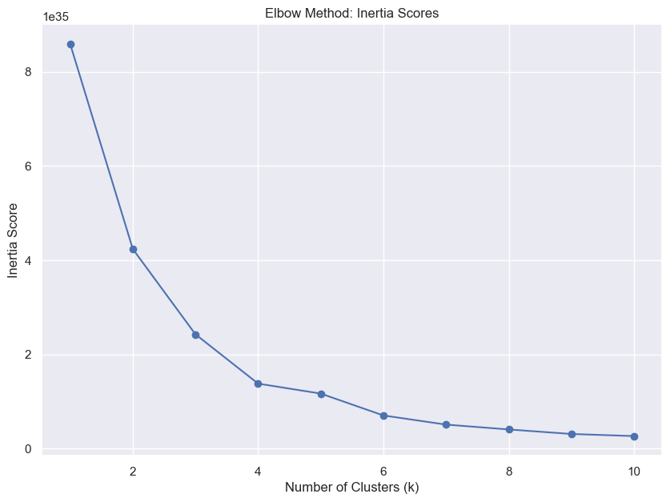

```python
X = prescription_patterns['TimeInterval'].values.reshape(-1, 1)

k_values = range(1, 11)
inertia_scores = []
cluster_mapping = {}

for k in k_values:
    kmeans = KMeans(n_clusters=k, n_init='auto', random_state=42)   # init will by default be done using k++ which is the best one to go with...
    kmeans.fit(X)

    inertia_score = kmeans.inertia_
    inertia_scores.append(inertia_score)

    cluster_mapping[f'{k} Cluster' if k == 1 else f'{k} Clusters'] = inertia_score

print(cluster_mapping)

sns.set_theme()
plt.figure(figsize=(10, 7))
plt.plot(k_values, inertia_scores, marker='o')
plt.xlabel('Number of Clusters (k)')
plt.ylabel('Inertia Score')
plt.title('Elbow Method: Inertia Scores')
plt.show()
```

4 clusters looks good... If had some more time, I could have plotted silhoutte score plot, davis bouldin score plot and calinski score plot to check the quality of clusters and that would have added some strength to our n-clusters pick...So, here let's go with 4 clusters and visualize patterns...

During my previous clustering project, I encountered huge delay in computing silhoutte, davis bouldin and calinski scores for say n-clusters in the range of [1, 10]... That's the main reason why I am skipping it here considering time constraint...

Now, let's do clustering with 4 no. of clusters with k-means...

### Clustering:

```python
kmeans = KMeans(n_clusters=4, random_state=42)
prescription_patterns['Cluster'] = kmeans.fit_predict(X) + 1

# Cluster by default will start from 0... For our understandability we are making it start from 1
```

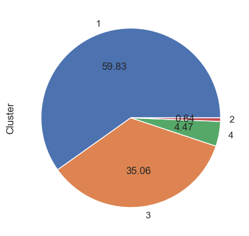

```python
prescription_patterns['Cluster'].value_counts().plot.pie(autopct='%.2f')
```

#### Instant observation:

- 95% patients falling in cluster 1 and 3 remaining 5% with cluster 2 and 4, that too in cluster, only around 0.6% patients are there.
- As obvious, Cluster 1 has more patients followed by Cluster 3.

Let's move forward and analyse further...

```python
prescription_patterns.head()
```

|  | Patient-Uid | Date | TimeInterval | Cluster |
| --- | --- | --- | --- | --- |
| 2094649 | a0e9c384-1c7c-11ec-81a0-16262ee38c7f | 2020-08-05 | 28 days | 3 |
| 2164002 | a0e9c384-1c7c-11ec-81a0-16262ee38c7f | 2020-09-02 | 28 days | 3 |
| 2637552 | a0e9c3b3-1c7c-11ec-ae8e-16262ee38c7f | 2018-05-17 | 23 days | 3 |
| 3171058 | a0e9c3b3-1c7c-11ec-ae8e-16262ee38c7f | 2018-06-13 | 27 days | 3 |
| 2375328 | a0e9c3b3-1c7c-11ec-ae8e-16262ee38c7f | 2018-08-07 | 55 days | 1 |

### Some Seggregation and Grouping before we get into visualization part...

```python
# Seggregating clusters into different dataframes to visualize wach of them with ease...

cluster_1 = prescription_patterns[prescription_patterns['Cluster'] == 1]
cluster_2 = prescription_patterns[prescription_patterns['Cluster'] == 2]
cluster_3 = prescription_patterns[prescription_patterns['Cluster'] == 3]
cluster_4 = prescription_patterns[prescription_patterns['Cluster'] == 4]
```

```python
# Grouping the data in each cluster by month and counting the number of prescriptions using Grouper object and groupby method

cluster_1_counts = cluster_1.groupby(pd.Grouper(key='Date', freq='M')).size()
cluster_2_counts = cluster_2.groupby(pd.Grouper(key='Date', freq='M')).size()
cluster_3_counts = cluster_3.groupby(pd.Grouper(key='Date', freq='M')).size()
cluster_4_counts = cluster_4.groupby(pd.Grouper(key='Date', freq='M')).size()
```

### Some first line of visualization before we dig deeper into the clusters...

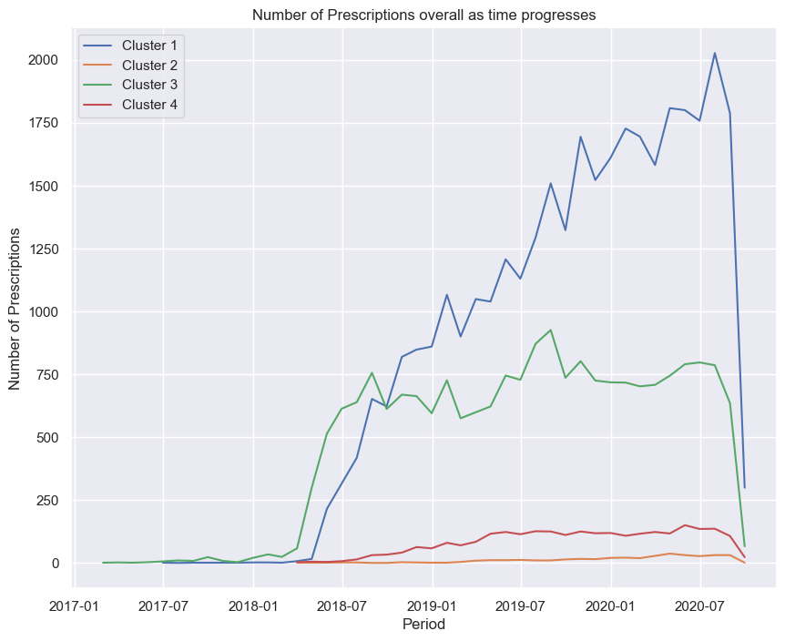

```python
plt.figure(figsize=(10, 8))

plt.plot(cluster_1_counts.index, cluster_1_counts.values, label='Cluster 1')
plt.plot(cluster_2_counts.index, cluster_2_counts.values, label='Cluster 2')
plt.plot(cluster_3_counts.index, cluster_3_counts.values, label='Cluster 3')
plt.plot(cluster_4_counts.index, cluster_4_counts.values, label='Cluster 4')

plt.xlabel('Period')
plt.ylabel('Number of Prescriptions')
plt.title('Number of Prescriptions overall as time progresses')
plt.legend()

plt.show()
```

### Inferences from above visualization:

As we already observed earlier in this same notebook, the `target drug administration` started only after `Feb 2017`.

### Creating new feature - Month from TimeInterval Column...

```python
cluster_1['Month'] = (cluster_1['TimeInterval'].dt.days / 30.44).astype(int)
cluster_2['Month'] = (cluster_2['TimeInterval'].dt.days / 30.44).astype(int)
cluster_3['Month'] = (cluster_3['TimeInterval'].dt.days / 30.44).astype(int)
cluster_4['Month'] = (cluster_4['TimeInterval'].dt.days / 30.44).astype(int)
```

```python
# Calculating the avg no. of prescriptions per unique patient for each month in each cluster

cluster_1_prescription = cluster_1.groupby(['Month', 'Patient-Uid']).size().groupby('Month').mean().reset_index(name='Average Prescriptions')
cluster_2_prescription = cluster_2.groupby(['Month', 'Patient-Uid']).size().groupby('Month').mean().reset_index(name='Average Prescriptions')
cluster_3_prescription = cluster_3.groupby(['Month', 'Patient-Uid']).size().groupby('Month').mean().reset_index(name='Average Prescriptions')
cluster_4_prescription = cluster_4.groupby(['Month', 'Patient-Uid']).size().groupby('Month').mean().reset_index(name='Average Prescriptions')
```

### Visualizations explaining the pattern in each cluster with respect to average prescriptions every month:

```python
std = cluster_1_prescription['Average Prescriptions'].std()    # standard deviation calculation for errorbar

error_y = np.full(len(cluster_1_prescription), std)

fig = go.Figure()
fig.add_trace(go.Scatter(
    x=cluster_1_prescription['Month'],
    y=cluster_1_prescription['Average Prescriptions'],
    error_y=dict(type='data', array=error_y, visible=True),
    mode='markers+lines',
    marker={'size': 16}
))

fig.update_layout(
    title='Average Prescriptions for Cluster 1',
    xaxis_title='Month',
    yaxis_title='Average Prescriptions'
)

fig.show()
```

[interactive chart not shown]

#### Insights gained:

- Patients in this cluster have `took the target drug for utmost 3 months`... As we have observed already, this group had the `most number of patients` in it... So, it should be safe to assume that almost close to **60% patient who took target drug in total across clusters has took it for only 3 months...**
- `Month 1` : On an average presciption is made atleast `thrice` in this month.
- `Month 2` : On an average presciption is made atleast `twice` this month.
- `Month 3` : On an average presciption is made atleast `once` this month.

So, the overall pattern in this cluster shows that, no. of prescriptions made on an average scale seems to be on a decreasing trend with the patients taking drug for 3 months to the max and then quit... This `doesn't seem to be healthy trend`... So, we have to make them more engaged in taking prescriptions...

```python
std = cluster_2_prescription['Average Prescriptions'].std()

error_y = np.full(len(cluster_2_prescription), std)

fig = go.Figure()
fig.add_trace(go.Scatter(
    x=cluster_2_prescription['Month'],
    y=cluster_2_prescription['Average Prescriptions'],
    error_y=dict(type='data', array=error_y, visible=True),
    mode='markers+lines',
    marker={'size': 16}
))

fig.update_layout(
    title='Average Prescriptions for Cluster 2',
    xaxis_title='Month',
    yaxis_title='Average Prescriptions'
)

fig.show()
```

[interactive chart not shown]

#### Insights gained:

- This cluster looks more of a `consistent and stable cluster`.
- `Starting from 9th month`, the prescription seems to be `consistent until 27th month (A span of 18 months)` where there's been **atleast 1 prescription every month** which looks pretty good and a `healthy trend` rather than having high no. of prescription on a month and falling down steeply in the subsequent months.
- `After 27th month until 32nd month` there seems to be `neglible or no prescription` and after that 32nd month the average was 1 and after that prescription has been taken post 3 months from 32nd month and 5 months from there on. Some patients might have had some `complications` which lead them to take target drug even after a span of 18 months period... This might also be because of the `reccurrent symptoms`...

So, the overall pattern looks `pretty much healthy` over here despite having few cuts here and there...

```python
std = cluster_3_prescription['Average Prescriptions'].std()

error_y = np.full(len(cluster_3_prescription), std)

fig = go.Figure()
fig.add_trace(go.Scatter(
    x=cluster_3_prescription['Month'],
    y=cluster_3_prescription['Average Prescriptions'],
    error_y=dict(type='data', array=error_y, visible=True),
    mode='markers+lines',
    marker={'size': 16}
))

fig.update_layout(
    title='Average Prescriptions for Cluster 3',
    xaxis_title='Month',
    yaxis_title='Average Prescriptions'
)

fig.show()
```

[interactive chart not shown]

#### Insights gained:

- These are the patient group who were the `earliest to take the target drug` as we observed before.
- `Initially` they seem to have taken around `3 prescriptions on an average.`
- `After first prescription`, there seems to be `steep decline` in average no. of prescription taken which almost became less than half of the initial month's average.
- These patients seem to have `stopped` taking target drug `within a month or so` making them the `worst amongst all that we have seen so far.`

Overall, patients in this cluster `represents the worst trend of all` that we have seen so far despite them being the **earliest drug takers** and **the second most no. of patient falling under this umbrella.**

```python
std = cluster_4_prescription['Average Prescriptions'].std()

error_y = np.full(len(cluster_4_prescription), std)

fig = go.Figure()
fig.add_trace(go.Scatter(
    x=cluster_4_prescription['Month'],
    y=cluster_4_prescription['Average Prescriptions'],
    error_y=dict(type='data', array=error_y, visible=True),
    mode='markers+lines',
    marker={'size': 16}
))

fig.update_layout(
    title='Average Prescriptions for Cluster 4',
    xaxis_title='Month',
    yaxis_title='Average Prescriptions'
)

fig.show()
```

[interactive chart not shown]

#### Insights gained:

- These group of patients all seem to have taken `around 1 drug on average throughout` from the 3rd month till 9th month `(A span of 6 months)` with slight decline from inital administration.
- Apart from that this cluster seems to be `a consistent and stable cluster` and `can be put next to the best performing cluster - cluster 2.`

Overall, this group though with **second least no. of people coming under this umbrella**, have **performed really upto the mark.** The span might just be because the parctitioner would have thought that these group just need to take for these many months... There might be other reasons as well.

### Overall Summary:

At first instance when we have seen that overall visualization, we might have got carried away... But, only when we digged deeper, we came to sense, which is quite contrary to what we might have thought.

- `Cluster 1 and Cluster 3` which have more than `95% of total patients` who took target drug, `performs poorly`. While `cluster 1` which has `60% of total patients` in it, seems to have had a `declining trend` and the patients in this cluster `took drug only for 3 months` whereas, `cluster 3` which has `35% of total patients` in it seems to be the `worst of all` that we have as it has patients who has `taken drug just for a month or so` and that too on a `declining trend.`
- `Cluster 2 and Cluster 4` which we would have thought as worst at first glance are the best actually. Among which `cluster 2` is the `best of all` that we have as they `took drug for a span of 18 months` which is `pretty much consistent` and they took `atleast 1 drug on average throughout`, which is `stable enough`. With respect to `cluster 4`, these patients follow a `similar trend` to that of cluster 2 `except` for the fact that it has a`slight decline` in no. of prescriptions and the `span` here is around `6 months` which sound pretty much fine and consistent.

So, this sums it up all. Had some more time, we could have explored it further... Thanks for the opportunity though...